# Graph Theory

# Can instead project to one-mode using correlation or standardized euclidean distances

Convert to a sociomatrix by running a **Pearson product-moment correlation** between all pairs of rows of the affiliation matrix

```r
cor1A_110 <- t(sub2_110)  %>% cor()
round(cor1A_110, 2)
```

```
##       S10   S22   S73   S84   S77   S32    S8   S27   S23   S36
## S10  1.00 -0.51  0.33 -0.76 -0.05  0.09  0.22 -0.51 -0.22  0.36
## S22 -0.51  1.00 -0.17  0.67 -0.22 -0.27 -0.33  1.00  0.67 -0.41
## S73  0.33 -0.17  1.00 -0.25 -0.33 -0.41  0.50 -0.17 -0.25 -0.10
## S84 -0.76  0.67 -0.25  1.00 -0.33  0.10  0.00  0.67  0.38 -0.10
## S77 -0.05 -0.22 -0.33 -0.33  1.00  0.36  0.22 -0.22  0.22  0.09
## S32  0.09 -0.27 -0.41  0.10  0.36  1.00  0.41 -0.27  0.10  0.67
## S8   0.22 -0.33  0.50  0.00  0.22  0.41  1.00 -0.33  0.00  0.41
## S27 -0.51  1.00 -0.17  0.67 -0.22 -0.27 -0.33  1.00  0.67 -0.41
## S23 -0.22  0.67 -0.25  0.38  0.22  0.10  0.00  0.67  1.00 -0.10
## S36  0.36 -0.41 -0.10 -0.10  0.09  0.67  0.41 -0.41 -0.10  1.00
```

# Can instead project to one-mode using correlation or standardized euclidean distances

Convert to a sociomatrix by running a **Pearson product-moment correlation** between all pairs of rows of the affiliation matrix

# Today’s Agenda

1. Moving from raw data to a network
2. Moving from a two-mode network to a one-mode projection
3. Direct and Indirect Relationships
4. Basic Descriptive Statistics

# $S^1$ represents the presence of **direct** (first-order) relationships

```r
# BINARIZE ONE-MODE SENATE SOCIOMATRIX
S1 <- ifelse(sub1A_110 > 0, 1, 0)
diag(S1) <- 0
```

|  | S10 | S22 | S73 | S84 | S77 | S32 | S8 | S27 | S23 | S36 |
| --- | --- | --- | --- | --- | --- | --- | --- | --- | --- | --- |
| S10 | 0 | 0 | 1 | 0 | 1 | 1 | 1 | 0 | 1 | 1 |
| S22 | 0 | 0 | 0 | 1 | 0 | 0 | 0 | 1 | 1 | 0 |
| S73 | 1 | 0 | 0 | 0 | 0 | 0 | 1 | 0 | 0 | 1 |
| S84 | 0 | 1 | 0 | 0 | 0 | 1 | 1 | 1 | 1 | 1 |
| S77 | 1 | 0 | 0 | 0 | 0 | 1 | 1 | 0 | 1 | 1 |
| S32 | 1 | 0 | 0 | 1 | 1 | 0 | 1 | 0 | 1 | 1 |
| S8 | 1 | 0 | 1 | 1 | 1 | 1 | 0 | 0 | 1 | 1 |
| S27 | 0 | 1 | 0 | 1 | 0 | 0 | 0 | 0 | 1 | 0 |
| S23 | 1 | 1 | 0 | 1 | 1 | 1 | 1 | 1 | 0 | 1 |
| S36 | 1 | 0 | 1 | 1 | 1 | 1 | 1 | 0 | 1 | 0 |

# Can find **second-order** indirect relationships with $S^2 = S \times S$

```r
S2 <- S1 %*% S1
```

|  | S10 | S22 | S73 | S84 | S77 | S32 | S8 | S27 | S23 | S36 |
| --- | --- | --- | --- | --- | --- | --- | --- | --- | --- | --- |
| S10 | 6 | 1 | 2 | 4 | 4 | 4 | 5 | 1 | 4 | 5 |
| S22 | 1 | 3 | 0 | 2 | 1 | 2 | 2 | 2 | 2 | 2 |
| S73 | 2 | 0 | 3 | 2 | 3 | 3 | 2 | 0 | 3 | 2 |
| S84 | 4 | 2 | 2 | 6 | 4 | 3 | 3 | 2 | 5 | 3 |
| S77 | 4 | 1 | 3 | 4 | 5 | 4 | 4 | 1 | 4 | 4 |
| S32 | 4 | 2 | 3 | 3 | 4 | 6 | 5 | 2 | 5 | 5 |
| S8 | 5 | 2 | 2 | 3 | 4 | 5 | 7 | 2 | 5 | 6 |
| S27 | 1 | 2 | 0 | 2 | 1 | 2 | 2 | 3 | 2 | 2 |
| S23 | 4 | 2 | 3 | 5 | 4 | 5 | 5 | 2 | 8 | 5 |
| S36 | 5 | 2 | 2 | 3 | 4 | 5 | 6 | 2 | 5 | 7 |

- represents “friend of a friend” relationships

# Can find **third-order** indirect relationships with $S^3 = S \times S^2$

```r
S3 <- S1 %*% S2
```

|  | S10 | S22 | S73 | S84 | S77 | S32 | S8 | S27 | S23 | S36 |
| --- | --- | --- | --- | --- | --- | --- | --- | --- | --- | --- |
| S10 | 24 | 9 | 16 | 20 | 24 | 28 | 29 | 9 | 30 | 29 |
| S22 | 9 | 6 | 5 | 13 | 9 | 10 | 10 | 7 | 15 | 10 |
| S73 | 16 | 5 | 6 | 10 | 12 | 14 | 18 | 5 | 14 | 18 |
| S84 | 20 | 13 | 10 | 18 | 18 | 25 | 27 | 13 | 27 | 27 |
| S77 | 24 | 9 | 12 | 18 | 20 | 25 | 28 | 9 | 27 | 28 |
| S32 | 28 | 10 | 14 | 25 | 25 | 26 | 30 | 10 | 31 | 30 |
| S8 | 29 | 10 | 18 | 27 | 28 | 30 | 30 | 10 | 34 | 31 |
| S27 | 9 | 7 | 5 | 13 | 9 | 10 | 10 | 6 | 15 | 10 |
| S23 | 30 | 15 | 14 | 27 | 27 | 31 | 34 | 15 | 32 | 34 |
| S36 | 29 | 10 | 18 | 27 | 28 | 30 | 31 | 10 | 34 | 30 |

- represents “friend of a friend of a friend” relationships
- Can find **p-order** indirect relationships by raising $S$ to the $p^{th}$ power

# A **reachability matrix** $S^R$ indicates whether actor $i$ can reach actor $j$ on a path of any length

To find the reachability matrix $S^R$:

1. $S^\sum = \sum^{n-1}_{p=1}S^p$
2. $s_{ij}^R=\begin{cases}1\text{ if } s_{ij}^\sum \geq 1 \\0\text{ otherwise}\end{cases}$

# A **reachability matrix** $S^R$ indicates whether actor $i$ can reach actor $j$ on a path of any length

```r
# CREATE 'NETWORK' OBJECT
S1net <- network(S1, directed = FALSE)

# FIND S^R
SR <- reachability(S1net)
```

[output not shown]

```r
SR
```

```
##       [,1] [,2] [,3] [,4] [,5] [,6] [,7] [,8] [,9] [,10]
##  [1,]    1    1    1    1    1    1    1    1    1     1
##  [2,]    1    1    1    1    1    1    1    1    1     1
##  [3,]    1    1    1    1    1    1    1    1    1     1
##  [4,]    1    1    1    1    1    1    1    1    1     1
##  [5,]    1    1    1    1    1    1    1    1    1     1
##  [6,]    1    1    1    1    1    1    1    1    1     1
##  [7,]    1    1    1    1    1    1    1    1    1     1
##  [8,]    1    1    1    1    1    1    1    1    1     1
##  [9,]    1    1    1    1    1    1    1    1    1     1
## [10,]    1    1    1    1    1    1    1    1    1     1
```

# If all actors can reach one another, the graph is **connected**

| 1 | 1 | 1 | 1 | 1 | 1 | 1 | 1 | 1 | 1 |
| --- | --- | --- | --- | --- | --- | --- | --- | --- | --- |
| 1 | 1 | 1 | 1 | 1 | 1 | 1 | 1 | 1 | 1 |
| 1 | 1 | 1 | 1 | 1 | 1 | 1 | 1 | 1 | 1 |
| 1 | 1 | 1 | 1 | 1 | 1 | 1 | 1 | 1 | 1 |
| 1 | 1 | 1 | 1 | 1 | 1 | 1 | 1 | 1 | 1 |
| 1 | 1 | 1 | 1 | 1 | 1 | 1 | 1 | 1 | 1 |
| 1 | 1 | 1 | 1 | 1 | 1 | 1 | 1 | 1 | 1 |
| 1 | 1 | 1 | 1 | 1 | 1 | 1 | 1 | 1 | 1 |
| 1 | 1 | 1 | 1 | 1 | 1 | 1 | 1 | 1 | 1 |
| 1 | 1 | 1 | 1 | 1 | 1 | 1 | 1 | 1 | 1 |

```r
is.connected(S1net)
```

[output not shown]

```
## [1] TRUE
```

# A **distance matrix** $D$ denotes the length of the shortest path betweeen $i$ and $j$

1. Raise S to successively higher powers
2. The first power $p$ for which element (i,j) exceeds zero is the shortest path length:

$$d(i,j) = min_p s_{ij}^{[p]} > 0$$

# A **distance matrix** $D$ denotes the length of the shortest path betweeen $i$ and $j$

```r
# FIND DISTANCE MATRIX
D <- geodist(S1net)$gdist
```

| 0 | 2 | 1 | 2 | 1 | 1 | 1 | 2 | 1 | 1 |
| --- | --- | --- | --- | --- | --- | --- | --- | --- | --- |
| 2 | 0 | 3 | 1 | 2 | 2 | 2 | 1 | 1 | 2 |
| 1 | 3 | 0 | 2 | 2 | 2 | 1 | 3 | 2 | 1 |
| 2 | 1 | 2 | 0 | 2 | 1 | 1 | 1 | 1 | 1 |
| 1 | 2 | 2 | 2 | 0 | 1 | 1 | 2 | 1 | 1 |
| 1 | 2 | 2 | 1 | 1 | 0 | 1 | 2 | 1 | 1 |
| 1 | 2 | 1 | 1 | 1 | 1 | 0 | 2 | 1 | 1 |
| 2 | 1 | 3 | 1 | 2 | 2 | 2 | 0 | 1 | 2 |
| 1 | 1 | 2 | 1 | 1 | 1 | 1 | 1 | 0 | 1 |
| 1 | 2 | 1 | 1 | 1 | 1 | 1 | 2 | 1 | 0 |

# The **diameter** of the graph is the largest entry in the distance matrix

- if the graph is not conneced, the **diameter** is undefined

| 0 | 2 | 1 | 2 | 1 | 1 | 1 | 2 | 1 | 1 |
| --- | --- | --- | --- | --- | --- | --- | --- | --- | --- |
| 2 | 0 | 3 | 1 | 2 | 2 | 2 | 1 | 1 | 2 |
| 1 | 3 | 0 | 2 | 2 | 2 | 1 | 3 | 2 | 1 |
| 2 | 1 | 2 | 0 | 2 | 1 | 1 | 1 | 1 | 1 |
| 1 | 2 | 2 | 2 | 0 | 1 | 1 | 2 | 1 | 1 |
| 1 | 2 | 2 | 1 | 1 | 0 | 1 | 2 | 1 | 1 |
| 1 | 2 | 1 | 1 | 1 | 1 | 0 | 2 | 1 | 1 |
| 2 | 1 | 3 | 1 | 2 | 2 | 2 | 0 | 1 | 2 |
| 1 | 1 | 2 | 1 | 1 | 1 | 1 | 1 | 0 | 1 |
| 1 | 2 | 1 | 1 | 1 | 1 | 1 | 2 | 1 | 0 |

```r
max(D)
```

```
## [1] 3
```

# Today’s Agenda

1. Moving from raw data to a network
2. Moving from a two-mode network to a one-mode projection
3. Direct and Indirect Relationships
4. Basic Descriptive Statistics

# The **degree** of node $i$ represents the number of edges it has

$$\text{degree}_i = \sum^n_{j = 1} s_{ij}$$

# The **degree** of node $i$ represents the number of edges it has

```r
data.frame(
  id = S1net %v% "vertex.names",
  degree = degree(S1net, gmode = "graph")
)
```

```
##     id degree
## 1  S10      6
## 2  S22      3
## 3  S73      3
## 4  S84      6
## 5  S77      5
## 6  S32      6
## 7   S8      7
## 8  S27      3
## 9  S23      8
## 10 S36      7
```

# Networks are often summarized by their **degree distribution**

```r
degree(S1net, gmode = "graph")  %>% table()
```

```
## .
## 3 5 6 7 8
## 3 1 3 2 1
```

# The **density $\Delta$** of a graph equals the proportion of possible edges that exist in the graph

$$\Delta = \frac{\text{Observed Edges}}{\text{Possible Edges}} = \frac{\sum_{i = 1}^n \sum_{j = 1}^n s_{ij}}{n(n - 1)}$$

```r
sum(S1)/(nrow(S1) * (nrow(S1) - 1))
```

```
## [1] 0.6
```

```r
gden(S1net)
```

```
## [1] 0.6
```

The **Transitivity** of a triad means that when there is a tie from i to j, and also from j to k, then there is also a tie from i to k

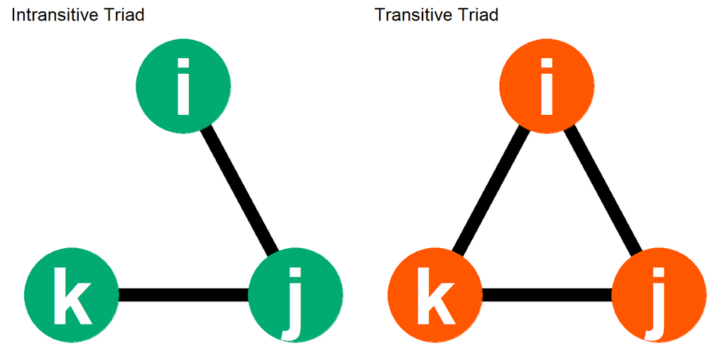

If $S^2_{ik} \geq 1$, the relation is **transitive** if $x_{ik} = 1$

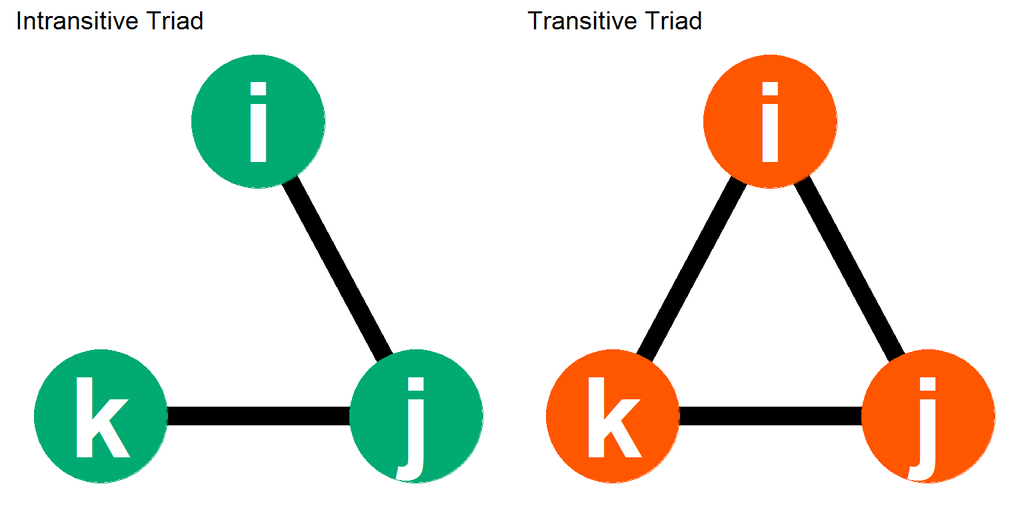

# Assignment 1

- Find network data
  - Must be unweighted and undirected
- Briefly describe the data: what do the nodes and edges represent?
- Create a sociogram of the network
  - If the data contain multiple time points, choose a single time point
- Use the material from this lecture and Wasserman & Faust chapters 3-4 to describe features of the network
- Speculate about the processes that may have contributed to the particular patterns
- Resources:
  - [creating sociograms in igraph and network](https://rpubs.com/kateto/netviz)
  - [creating sociograms in ggnetwork](https://briatte.github.io/ggnetwork/)
  - [database of network datasets](https://icon.colorado.edu/#!/)
  - [How to create PDFs with R Markdown](http://rmarkdown.rstudio.com/pdf_document_format.html)